# Crickets

Heath Blackmon

8/17/2018

## The data and experiment

Moran, Ritche, and Bailey published an article asking if X chromosomes are key to hybrid incompatibilities in crickets with an XO sex chromosome system. However, the analysis of their data seemed less than ideal to me. They used binomial tests to check for deviations from equal sex ratio (this seems appropriate) and then they used a GLM where the predictor was female X chromosome identity and a covariate of female weight. In and of itself this approach does not seem bad it can tell us if X chromosomes matter. However, that is about as much as it can tell us. We could get a much more nuanced picture of what is going on if they had used a line cross analysis. In this approach, we fit a GLM, but now the predictors are all the different types of gene action that might explain a trait of interest. For instance, a trait might be determined purely by many genes acting additively in this case we expect F1 to have a phenotype that falls exactly between the two parental strains (line cross is explained in depth in Lynch and Walsh textbook).

Lets look at what happens if we reanalyze their egg data with line cross analysis.

```r
dat <- read.csv("eggs.csv")
head(dat)
```

```
##   cross   mean        SE sex enviro sire dam
## 1    P1 177.80 33.187721   E      1    1   1
## 2    P2 363.12 38.126600   E      1    2   2
## 3    F1  84.00 27.750000   E      1    1   2
## 4   F1r 239.56 34.281134   E      1    2   1
## 5  BC2a   3.45  1.670343   E      1    1   4
## 6  BC1a  15.30  2.101904   E      1    1   3
```

So I have just reformated their data from sup table 1. I should note that this table includes controls in line 3-4 under the heading F1 and in line 17-18 under BC2 cross. I am not sure why they have two sets of control crosses or what they are controlling for - can find no mention of it in the manuscript or sup. I have chosen to just use that first set on lines 3-4. To do this analysis we will use the latest version of my software SAGA2 it is still on github so we will use devtools to install the latest version.

```
library(devtools)
install_github("coleoguy/SAGA2")
```

```r
library(SAGA2)
res <- LCA(dat, max.pars = 4)
```

```
## The composite genetic effects that will be tested are:
##  Aa, Ad, Xa, Xd, Ya, Ca, Mea, Med, AaAa, AaAd, AaXa, AaXd, AaYa, AaCa, AdAd, AdXa, AdXd, AdYa, AdCa, XaXa, XaXd, XaYa, XaCa, XdXd, XdYa, XdCa, YaCa
## Since there are 20853 possible models this may take a bit:
## Generating Models....
##  5000
##  10000
##  15000
##  20000
## 123 models were removed due to high covariances
## or linear relationships between predictor variables.
## The remaining 20730 models have been evaluated.
##
##
## AICc weights were used to select the minimum number of models whose weights sum
## to greater than 95% this model set includes 4684 model(s)
```

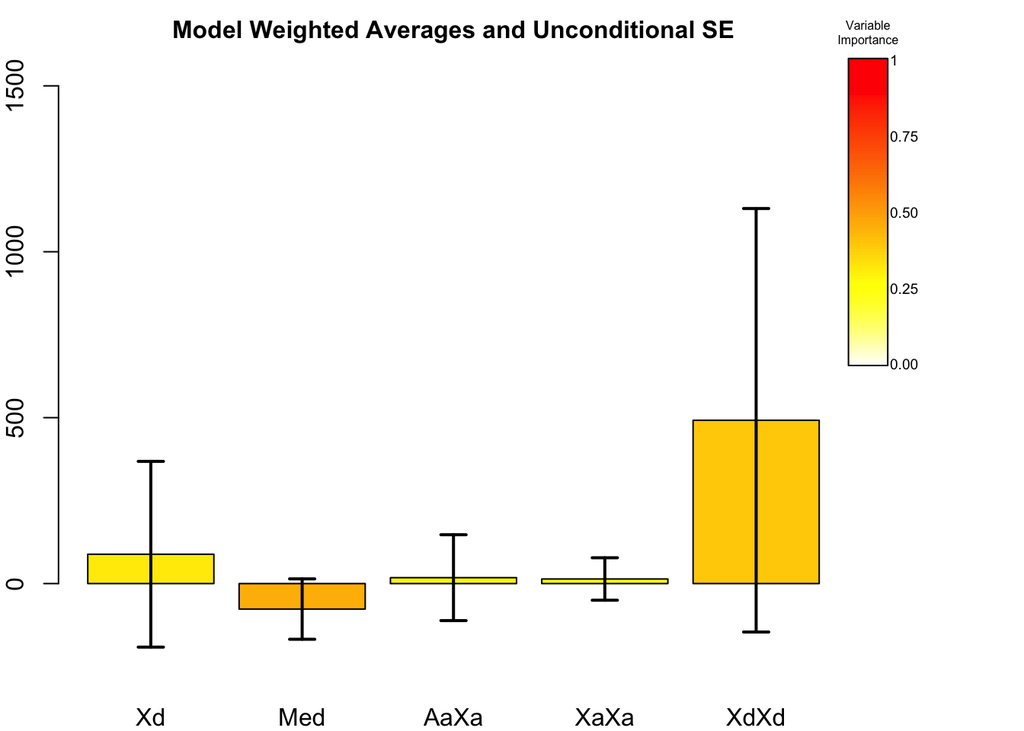

```r
plot(res, min.vi=.25)
```